# Lab 10: Priors, Posteriors, and Checking the Sampler

ECON 8310: Business Forecasting — University of Nebraska at Omaha

# What we are doing

Every model so far returned a number. Today’s returns a **distribution**, and the work shifts accordingly: less about fitting, more about deciding what you believe beforehand and checking whether the machinery actually worked.

The question is small on purpose so the workflow stays visible: **what fraction of weeks are high-SNAP weeks at CA_1 FOODS?** You will state a prior, check it before looking at the data, fit the model, verify the sampler, and then ask the posterior questions no point estimate can answer.

**Suggested time:** ~35 minutes · **You will need:** `pandas`, `numpy`, `matplotlib`, `pymc`, `arviz`, and `data/processed/m5_weekly.csv`. Each fit takes about ten seconds.

# Setup

```python
import pandas as pd
import numpy as np
import matplotlib.pyplot as plt
import pymc as pm
import arviz as az
import warnings, logging
warnings.filterwarnings('ignore')
logging.getLogger('pymc').setLevel(logging.ERROR)

from pathlib import Path

def data_path(name):
    for base in (Path.cwd(), *Path.cwd().parents):
        p = base / "data" / "processed" / name
        if p.exists():
            return p
    raise FileNotFoundError(
        f"Could not find data/processed/{name}. "
        "Run `python scripts/prep_m5.py` from the repository root first.")

weekly = pd.read_csv(data_path("m5_weekly.csv"), parse_dates=["week_start"])
ca1 = weekly[(weekly.store_id == "CA_1") & (weekly.cat_id == "FOODS")]

N_WEEKS = len(ca1)
N_HIGH  = int((ca1.snap_days >= 5).sum())
print(f"CA_1 FOODS: {N_HIGH} high-SNAP weeks out of {N_WEEKS} "
      f"({100*N_HIGH/N_WEEKS:.0f}% observed)")
```

```
CA_1 FOODS: 72 high-SNAP weeks out of 277 (26% observed)
```

**ArviZ changed its default interval**

`az.summary(idata)` now reports an **89% equal-tailed interval** (`eti89_lb`, `eti89_ub`). This course uses the **highest density interval**, which is the *shortest* interval containing a given probability mass.

Always ask for it: `az.summary(idata, ci_kind="hdi", ci_prob=0.94)`.

For a symmetric posterior the two nearly coincide. For a skewed one they do not, and the HDI is the honest summary.

# Step 1 — Check the prior before you use it

We will model the count of high-SNAP weeks as Beta-Binomial. Start with `Beta(2, 2)` — weakly informative, centered at 0.5.

**Before fitting anything**, ask what that prior alone implies about the data.

```
prior predictive spans 8 to 276 weeks
```

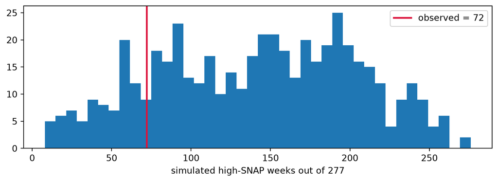

```python
with pm.Model() as model:
    theta = pm.Beta("theta", alpha=2, beta=2)
    obs   = pm.Binomial("obs", n=N_WEEKS, p=theta, observed=N_HIGH)
    prior_pred = pm.sample_prior_predictive(500, random_seed=42)

sim = prior_pred.prior_predictive["obs"].values.ravel()
fig, ax = plt.subplots(figsize=(8, 3))
ax.hist(sim, bins=40)
ax.axvline(N_HIGH, color="crimson", lw=2, label=f"observed = {N_HIGH}")
ax.set_xlabel("simulated high-SNAP weeks out of 277"); ax.legend()
plt.tight_layout()
print(f"prior predictive spans {sim.min()} to {sim.max()} weeks")
```

**Read the plot.** The prior thinks almost any count is plausible — from nearly zero to nearly every week. The observed value sits comfortably inside, so the prior is not *wrong*.

But is it *good*? SNAP is disbursed on a published calendar. We are not genuinely ignorant here, and a prior that entertains “every week is a high-SNAP week” is entertaining something we know is false.

# Step 2 — Fit it

```python
with model:
    idata = pm.sample(2000, tune=1000, chains=4, progressbar=False, random_seed=42)

summary = az.summary(idata, ci_kind="hdi", ci_prob=0.94)
print(summary.round(4).to_string())
```

```
         mean     sd hdi94_lb hdi94_ub ess_bulk ess_tail r_hat mcse_mean  mcse_sd
theta  0.2628  0.026     0.22     0.31     3686     5175  1.00   0.00043  0.00031
```

The posterior mean sits between the prior mean of 0.5 and the observed proportion — much closer to the data, because 277 observations carry far more weight than a `Beta(2, 2)` prior.

# Step 3 — Did the sampler work?

MCMC always returns samples. Whether they came from the posterior is a separate question, and one you are expected to answer every time.

```
R-hat        1.001    (want < 1.01)
ESS (bulk)   3687      (want > 400)
divergences  0        (want 0)
```

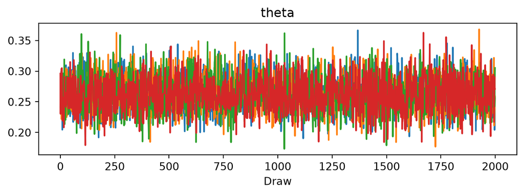

```python
n_div = int(idata.sample_stats.diverging.sum())
print(f"R-hat        {summary.r_hat.max():.3f}    (want < 1.01)")
print(f"ESS (bulk)   {summary.ess_bulk.min():.0f}      (want > 400)")
print(f"divergences  {n_div}        (want 0)")

az.plot_trace(idata, var_names=["theta"]);
plt.tight_layout()
```

If the chains had separated, $\hat{R}$ would exceed 1.01 and nothing downstream would mean anything.

# Step 4 — Ask the posterior a question

The posterior is a set of samples, so any question about $\theta$ is answered by counting.

```python
theta = idata.posterior["theta"].values.ravel()

print(f"P(theta > 0.30)          = {(theta > 0.30).mean():.3f}")
print(f"P(0.24 < theta < 0.28)   = {((theta > 0.24) & (theta < 0.28)).mean():.3f}")
print(f"94% HDI                  = {np.round(az.hdi(theta, prob=0.94), 4)}")
```

```
P(theta > 0.30)          = 0.080
P(0.24 < theta < 0.28)   = 0.558
94% HDI                  = [0.2132 0.3098]
```

**Say the first line out loud as a sentence a manager would understand.** Then notice you cannot say anything of that form from a confidence interval — a frequentist 94% interval is a statement about the procedure, not about $\theta$.

# Step 5 — How much did the prior matter?

The honest objection to Bayesian work is that the prior is arbitrary. Test how much it moves the answer.

```python
rows = []
for a, b, label in [(2, 2, "Beta(2,2) — weak, centered 0.5"),
                    (5, 15, "Beta(5,15) — informed, centered 0.25"),
                    (20, 2, "Beta(20,2) — badly wrong, centered 0.91")]:
    with pm.Model():
        th = pm.Beta("theta", alpha=a, beta=b)
        pm.Binomial("obs", n=N_WEEKS, p=th, observed=N_HIGH)
        i2 = pm.sample(1000, tune=1000, chains=2, progressbar=False, random_seed=42)
    s = az.summary(i2, ci_kind="hdi", ci_prob=0.94)
    rows.append({"prior": label, "prior_mean": round(a/(a+b), 3),
                 "posterior_mean": round(float(s["mean"].iloc[0]), 3)})
print(pd.DataFrame(rows).to_string(index=False))
```

```
                                  prior  prior_mean  posterior_mean
         Beta(2,2) — weak, centered 0.5       0.500           0.265
   Beta(5,15) — informed, centered 0.25       0.250           0.259
Beta(20,2) — badly wrong, centered 0.91       0.909           0.309
```

**With enough data the prior is outweighed, not erased**

Three priors, including one centered on 0.91 — badly, deliberately wrong. The posterior means land at 0.265, 0.259 and 0.309: 277 observations outweigh a prior worth 22 observations, so even the wrong one is dragged most of the way to the data.

Most of the way is not all of the way. The wrong prior moves P(θ > 0.30) from 0.080 (Step 4) to about 0.61. Count it from `i2`, which still holds that fit. A shift of 0.04 in the mean flips the answer to a question whose threshold sits close by.

Which is exactly the situation Lecture 11 Part 2 is about.

**Your turn:** re-run the badly-wrong prior against only the **first 10 weeks** of data and report how far the posterior moves.

```python
# ---- your turn: uncomment and fill in ----
# n_small, k_small = 10, int((ca1.snap_days >= 5).head(10).sum())
# with pm.Model():
#     th = pm.Beta("theta", alpha=___, beta=___)      # <- the badly-wrong prior
#     pm.Binomial("obs", n=n_small, p=th, observed=k_small)
#     i3 = pm.sample(1000, tune=1000, chains=2, progressbar=False, random_seed=42)
# print(az.summary(i3, ci_kind="hdi", ci_prob=0.94).round(3).to_string())
```

# Before you leave

> **Discuss (the prior):** Your Step 5 table says a deliberately wrong prior moved the posterior mean by only about 0.04, yet it moves P(θ > 0.30) from 0.08 to about 0.61. Under what circumstances would you *not* be reassured by a small shift in the mean, and what would you check?

> **Discuss (the check):** You verified $\hat{R}$, ESS and divergences before reading any result. Name the equivalent check you have been doing all semester for a non-Bayesian model, and say which is easier to skip.

> **Discuss (for Homework 6):** Part 1 asks you to run a prior predictive check and propose a better prior than `Beta(2, 2)` for a rate you know is roughly a quarter. What `alpha` and `beta` would you choose, and how would you defend the strength of it rather than just the center?

*Solutions posted to Canvas after class.*